# AID Clase 8

Débora Chan - Cecilia Oliva

15 de junio de 2019

# Comparación de Medias (caso univariado)

```r
#recordar instalar los paquetes si no están instalados aún
#library(ggplot2)
#library(stats)
#library(reshape2)
#library(car)
#library(nortest)
#library(openintro)
```

### Ejemplo 1: Muestras normales, independientes con misma varianza

El dataset “births” del paquete openintro contiene información sobre 150 nacimientos junto con información de las madres. Se quiere determinar si existen evidencias significativas de que el peso (en libras) de los recién nacidos cuyas madres fuman difiere de aquellos cuyas madres no fuman. Se considerarán sólo los casos con peso no inferior a 5 libras (aprox. 2.27 kg) para analizar muestras normales.

```r
data(births)
head(births,4)
```

```
##   fAge mAge weeks premature visits gained weight sexBaby     smoke
## 1   31   30    39 full term     13      1   6.88    male    smoker
## 2   34   36    39 full term      5     35   7.69    male nonsmoker
## 3   36   35    40 full term     12     29   8.88    male nonsmoker
## 4   41   40    40 full term     13     30   9.00  female nonsmoker
```

```r
dim(births)
```

```
## [1] 150   9
```

```r
births2<-births[which(births$weight>=5),]
dim(births2)
```

```
## [1] 138   9
```

#### Test a plantear: H0 vs H1

H0: las medias de los pesos de ambos grupos son iguales

H1: las medias de los pesos de ambos grupos son distintas

```r
#Estadístico observado:
mean(births2[births2$smoke == "nonsmoker", "weight"]) - mean(births2[births2$smoke == "smoker", "weight"])
```

```
## [1] 0.2749247
```

#### Analizamos normalidad:

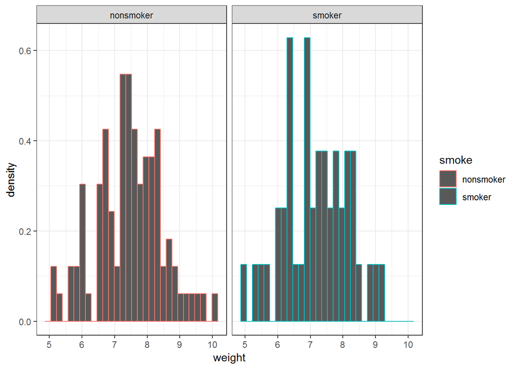

```r
ggplot(births2, aes(x = weight)) +
geom_histogram(aes(y = ..density.., colour = smoke)) +
facet_grid(. ~ smoke) + theme_bw()
```

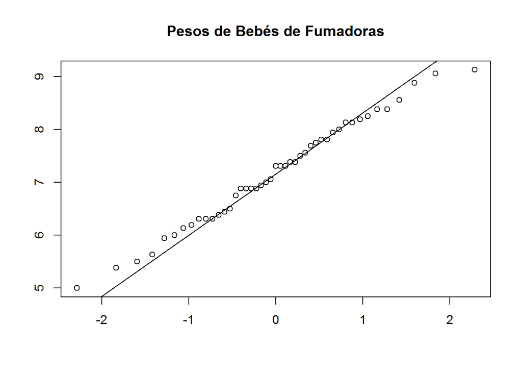

```r
qqnorm(births2[births2$smoke == "smoker", "weight"], xlab = "", ylab = "", main = "Pesos de Bebés de Fumadoras")
qqline(births2[births2$smoke == "smoker", "weight"])
```

```r
shapiro.test(births2[births2$smoke == "smoker","weight"])
```

```
##
##  Shapiro-Wilk normality test
##
## data:  births2[births2$smoke == "smoker", "weight"]
## W = 0.98664, p-value = 0.877
```

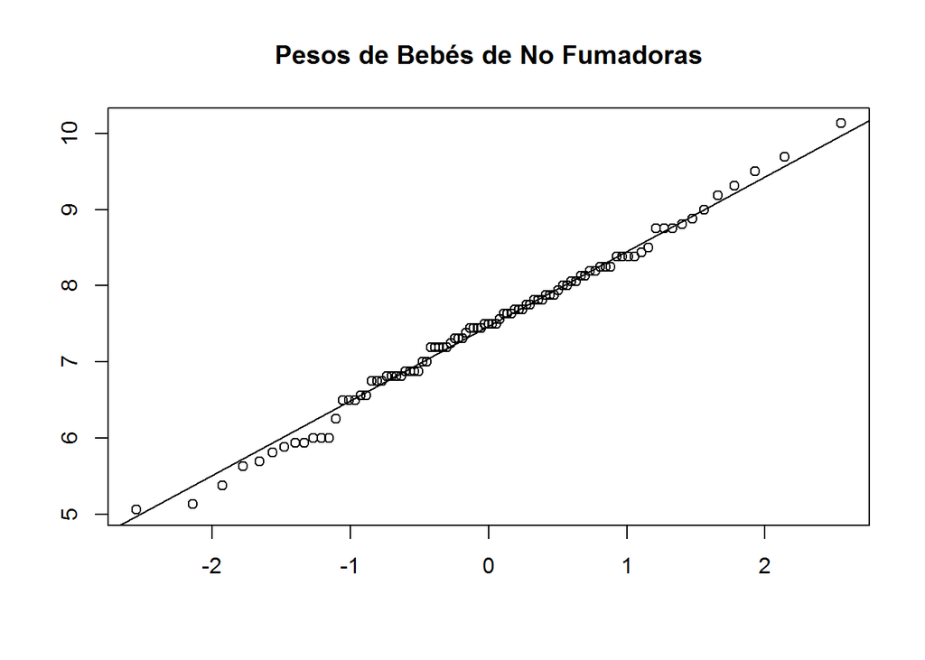

```r
qqnorm(births2[births2$smoke == "nonsmoker", "weight"], xlab = "", ylab = "", main = "Pesos de Bebés de No Fumadoras")
qqline(births2[births2$smoke == "nonsmoker", "weight"])
```

```r
shapiro.test(births2[births2$smoke == "nonsmoker","weight"])
```

```
##
##  Shapiro-Wilk normality test
##
## data:  births2[births2$smoke == "nonsmoker", "weight"]
## W = 0.99223, p-value = 0.8672
```

Los gráficos qqnorm muestran quantiles alineados a los quantiles de una distribución normal, y los tests de Shapiro-Wilk no encuentran evidencias significativas para rechazar que los datos proceden de poblaciones con distribución normal.

#### Analizamos igualdad de varianzas:

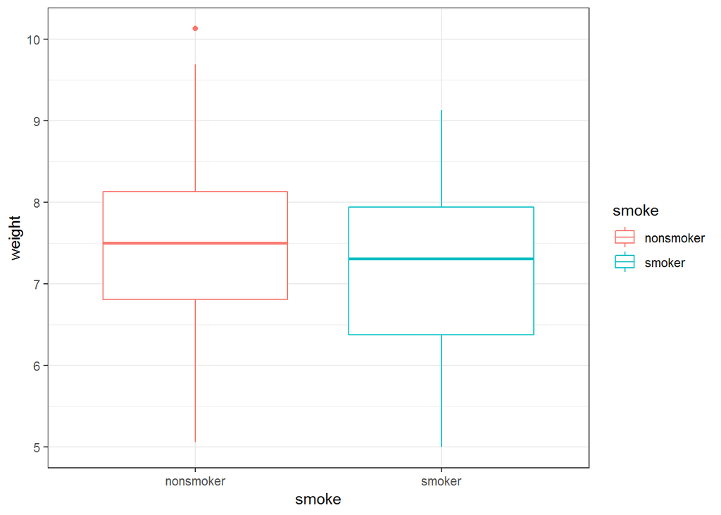

```r
ggplot(births2) + geom_boxplot(aes(x = smoke, y = weight, colour = smoke)) + theme_bw()
```

```r
leveneTest(weight ~ smoke, data = births2)
```

```
## Levene's Test for Homogeneity of Variance (center = median)
##        Df F value Pr(>F)
## group   1  0.1004 0.7518
##       136
```

Con los resultados obtenidos, no hay evidencia de diferencia de varianzas.

Luego, se cumplen las tres condiciones: independencia, normalidad e igual varianza (homoscedasticidad u homogeneidad de varianza). Aplicamos entonces el test t:

```r
t.test(x = births2[births2$smoke == "smoker", "weight"], y = births2[births2$smoke == "nonsmoker", "weight"], alternative = "two.sided", mu = 0, var.equal = TRUE, conf.level = 0.95)
```

```
##
##  Two Sample t-test
##
## data:  births2[births2$smoke == "smoker", "weight"] and births2[births2$smoke == "nonsmoker", "weight"]
## t = -1.4905, df = 136, p-value = 0.1384
## alternative hypothesis: true difference in means is not equal to 0
## 95 percent confidence interval:
##  -0.63969755  0.08984808
## sample estimates:
## mean of x mean of y
##  7.180667  7.455591
```

Conclusión: no hay suficiente evidencia para rechazar que la media de pesos de bebés de mamás fumadoras es igual a la media de pesos de bebés de mamás no fumadoras. Notar que el intervalo de confianza contiene al 0, es decir, con un 95% de confianza la diferencia de medias cae en un intervalo con valores cercanos a 0.

### Ejemplo 2: Muestras apareadas (dependientes)

Un equipo de atletismo ha decidido contratar a un nuevo entrenador. Para decidir si al cabo de un año mantienen su contrato se selecciona aleatoriamente a 10 miembros del equipo y se cronometran sus tiempos en 100 metros lisos al inicio del año, al final del año se volverá a cronometrar a esos mismos 10 corredores. En vista de los datos obtenidos ¿Hay diferencia significativa entre el rendimiento de los corredores tras un año de entrenar con el nuevo instructor? Se trata de un caso de estudio en el que las mediciones se realizan sobre los mismos individuos bajo dos condiciones distintas, se trata de datos pareados.

```r
datos <- data.frame(corredor = c(1:10), antes = c(12.9, 13.5, 12.8, 15.6, 17.2, 19.2, 12.6, 15.3, 14.4, 11.3), despues = c(12.7, 13.6, 12, 15.2, 16.8, 20, 12, 15.9, 16, 11.1))
head(datos, 4)
```

```
##   corredor antes despues
## 1        1  12.9    12.7
## 2        2  13.5    13.6
## 3        3  12.8    12.0
## 4        4  15.6    15.2
```

```r
diferencia <- datos$antes - datos$despues
datos <- cbind(datos, diferencia)
head(datos, 4)
```

```
##   corredor antes despues diferencia
## 1        1  12.9    12.7        0.2
## 2        2  13.5    13.6       -0.1
## 3        3  12.8    12.0        0.8
## 4        4  15.6    15.2        0.4
```

```r
t.test(x = datos$antes, y = datos$despues, alternative = "two.sided", mu = 0, paired = TRUE, conf.level = 0.95)
```

```
##
##  Paired t-test
##
## data:  datos$antes and datos$despues
## t = -0.21331, df = 9, p-value = 0.8358
## alternative hypothesis: true difference in means is not equal to 0
## 95 percent confidence interval:
##  -0.5802549  0.4802549
## sample estimates:
## mean of the differences
##                   -0.05
```

¿Qué conclusión obtenemos?

### Ejemplo 3: Tests no paramétricos de Mann Whitney Wilcoxon y de la Mediana para 2 muestras independientes

Se dispone de dos muestras, de las que no se conoce el tipo de distribución de las poblaciones de origen y cuyo tamaño es demasiado pequeño para determinar si siguen una distribución normal. ¿Existe una diferencia significativa entre poblaciones?

```r
muestra1 <- c( 1.1, 3.4, 4.3, 2.1, 7.0 , 2.5 )
muestra2 <- c( 7.0, 8.0, 3.0, 5.0, 6.2 , 4.4 )
wilcox.test(x = muestra1, y = muestra2, alternative = "two.sided", mu = 0, paired = FALSE, conf.int = 0.95)
```

```
##
##  Wilcoxon rank sum test with continuity correction
##
## data:  muestra1 and muestra2
## W = 6.5, p-value = 0.07765
## alternative hypothesis: true location shift is not equal to 0
## 95 percent confidence interval:
##  -4.9000274  0.4000139
## sample estimates:
## difference in location
##              -2.390035
```

```r
#install.packages("RVAideMemoire")
library(RVAideMemoire)
mood.medtest(muestra2~muestra1)
```

```
##
##  Mood's median test
##
## data:  muestra2 by muestra1
## p-value = 1
```

¿Qué conclusión obtenemos?

### Ejemplo 4: ANOVA de 1 factor

Se desea analizar los datos de un experimento para estudiar el efecto del porcentaje de algodón sobre la resistencia a la tensión de una fibra sintética.

```r
porcentaje<-c(rep(15,5),rep(20,5),rep(25,5),rep(30,5),rep(35,5))
resistencia<-c(7,7,15,11,9,12,17,12,18,18,14,18,18,19,19,19,25,22,19,23,7,10,11,15,11)
porcAlgodon <-data.frame(porcentaje,resistencia)
attach(porcAlgodon)
```

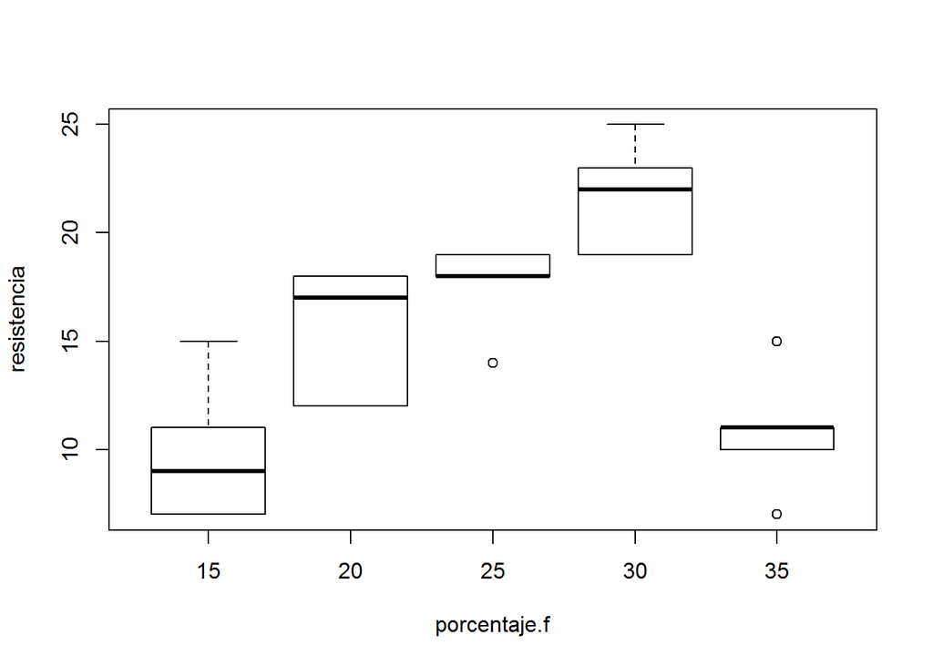

```r
porcentaje.f=factor(porcentaje)

plot(resistencia~porcentaje.f)# idem boxplot(resistencia~porcentaje.f)
```

```r
AOVporcAlgo<- aov(resistencia~porcentaje.f)
summary(AOVporcAlgo)#idem usando anova(AOVporcAlgo)
```

```
##              Df Sum Sq Mean Sq F value   Pr(>F)
## porcentaje.f  4  475.8  118.94   14.76 9.13e-06 ***
## Residuals    20  161.2    8.06
## ---
## Signif. codes:  0 '***' 0.001 '**' 0.01 '*' 0.05 '.' 0.1 ' ' 1
```

Aplicando ANOVA el p-valor=9.13e-06 es <0.05, por lo tanto, si se verifican los supuestos de normalidad y homogeneidad de la varianza será válido decir que se rechaza que las medias de cada grupo son todas iguales entre sí, es decir, hay al menos un par que difieren, por lo tanto los porcentajes de algodon influyen sobre la resistencia.

Veamos si se cumplen los supuestos necesarios para aplicar ANOVA.

#### Analizamos igualdad de varianzas:

```r
bartlett.test(resistencia,porcentaje.f)
```

```
##
##  Bartlett test of homogeneity of variances
##
## data:  resistencia and porcentaje.f
## Bartlett's K-squared = 0.93309, df = 4, p-value = 0.9198
```

```r
leveneTest(resistencia~porcentaje.f)
```

```
## Levene's Test for Homogeneity of Variance (center = median)
##       Df F value Pr(>F)
## group  4  0.3179 0.8626
##       20
```

#### Analizamos normalidad:

```r
shapiro.test(residuals(AOVporcAlgo))
```

```
##
##  Shapiro-Wilk normality test
##
## data:  residuals(AOVporcAlgo)
## W = 0.94387, p-value = 0.1818
```

```r
ad.test(residuals(AOVporcAlgo))
```

```
##
##  Anderson-Darling normality test
##
## data:  residuals(AOVporcAlgo)
## A = 0.51857, p-value = 0.1699
```

```r
library(moments)
agostino.test(residuals(AOVporcAlgo))
```

```
##
##  D'Agostino skewness test
##
## data:  residuals(AOVporcAlgo)
## skew = 0.10554, z = 0.25734, p-value = 0.7969
## alternative hypothesis: data have a skewness
```

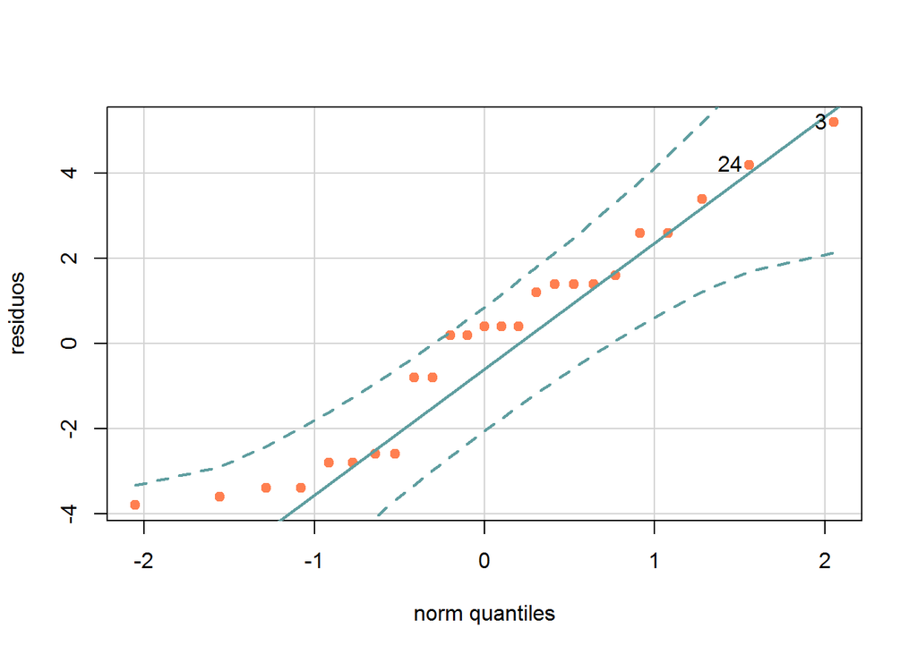

```
## [1]  3 24
```

```r
qqPlot(residuals(AOVporcAlgo),ylab = "residuos", col = "coral",pch = 19, col.lines = "cadetblue")
```

Los intervalos de confianza simultáneos para las diferencias de medias de Tukey resultan:

```r
TukeyHSD(AOVporcAlgo,conf.level=0.95)
```

```
##   Tukey multiple comparisons of means
##     95% family-wise confidence level
##
## Fit: aov(formula = resistencia ~ porcentaje.f)
##
## $porcentaje.f
##        diff         lwr        upr     p adj
## 20-15   5.6   0.2270417 10.9729583 0.0385024
## 25-15   7.8   2.4270417 13.1729583 0.0025948
## 30-15  11.8   6.4270417 17.1729583 0.0000190
## 35-15   1.0  -4.3729583  6.3729583 0.9797709
## 25-20   2.2  -3.1729583  7.5729583 0.7372438
## 30-20   6.2   0.8270417 11.5729583 0.0188936
## 35-20  -4.6  -9.9729583  0.7729583 0.1162970
## 30-25   4.0  -1.3729583  9.3729583 0.2101089
## 35-25  -6.8 -12.1729583 -1.4270417 0.0090646
## 35-30 -10.8 -16.1729583 -5.4270417 0.0000624
```

¿Qué conclusión obtenemos?